# 重賞レース予測レポート【レース終了】

作成日時: 2026/06/21 16:28:23

☞ [マニュアル(pdf)](https://ryutoro-galois.github.io/keiba-predictor/manual/manual.pdf)

☞ 過去6年の同一レース結果: [2025年](https://ryutoro-galois.github.io/keiba-predictor/report/PredResult_2025y_raceDate_20250622_20250622.html), [2024年](https://ryutoro-galois.github.io/keiba-predictor/report/PredResult_2024y_raceDate_20240616_20240616.html), [2023年](https://ryutoro-galois.github.io/keiba-predictor/report/PredResult_2023y_raceDate_20230618_20230618.html), [2022年](https://ryutoro-galois.github.io/keiba-predictor/report/PredResult_2022y_raceDate_20220619_20220619.html), [2021年](https://ryutoro-galois.github.io/keiba-predictor/report/PredResult_2021y_raceDate_20210620_20210620.html), [2020年](https://ryutoro-galois.github.io/keiba-predictor/report/PredResult_2020y_raceDate_20200621_20200621.html)

☞ 過去4週間の別レース結果: [1週前(6/13-14)](https://ryutoro-galois.github.io/keiba-predictor/report/PredResult_2026y_raceDate_20260613_20260614.html), [2週前(6/7)](https://ryutoro-galois.github.io/keiba-predictor/report/PredResult_2026y_raceDate_20260607_20260607.html), [3週前(5/30-31)](https://ryutoro-galois.github.io/keiba-predictor/report/PredResult_2026y_raceDate_20260530_20260531.html), [4週前(5/23-24)](https://ryutoro-galois.github.io/keiba-predictor/report/PredResult_2026y_raceDate_20260523_20260524.html)

☞ netkeiba: [府中牝馬ステークス(GⅢ)](https://race.netkeiba.com/race/result.html?race_id=202605030611&rf=race_submenu), [しらさぎステークス(GⅢ)](https://race.netkeiba.com/race/result.html?race_id=202609030611&rf=race_submenu)

☞ レース結果(csv): [6/20-21](https://ryutoro-galois.github.io/keiba-predictor/csv/race_result_20260620_20260621.csv)

## 【レース結果(1)】人気と着順の関係

### 【府中牝馬ステークス(2026/06/21(日))】

[interactive chart not shown]

### 【しらさぎステークス(2026/06/21(日))】

【しらさぎステークス(GⅢ)】  
2026/06/21(日), 09_阪神, 芝1600m

[interactive chart not shown]

## 【レース結果(2)】コーナー通過順位

### 【府中牝馬ステークス(2026/06/21(日))】

[interactive chart not shown]

### 【しらさぎステークス(2026/06/21(日))】

【しらさぎステークス(GⅢ)】  
2026/06/21(日), 09_阪神, 芝1600m

[interactive chart not shown]

## 0. 推し馬予測 (AI予測)

- 本命(◎): 1-3着内確率(勝負強さ)が1位の馬
- 対抗(◯): 1-3着内確率が2-N位(20%程度以上)の中で予測タイムが最も速い馬
- 3番手(▲): 1-3着内確率が2-N位(20%程度以上)のでダークホース確率が最も高い馬
- 穴: ダークホース確率が上位1-M位(40%程度以上)の中で1-3着内確率が最も高い馬

| 推し馬 | 枠番 | 馬番 | 人気 | オッズ | 馬名 | 騎手 | 調教師 | 予測タイム(sec) | 1_順位 | 1-3着内確率(%) | 2_順位 | ﾀﾞｰｸﾎｰｽ確率(%) | 3_順位 |
| --- | --- | --- | --- | --- | --- | --- | --- | --- | --- | --- | --- | --- | --- |
| 本命(◎) | 4 | 8 | 2 | 5.6 | ニシノティアモ | 津村明秀 | 上原佑紀 | 110.8 | 11.0 | 29.2 | 1 | 0.5 | 16 |
| 対抗(◯) | 8 | 15 | 6 | 12.6 | ルージュソリテール | 西塚洸二 | 藤原英昭 | 108.3 | 3.0 | 21.5 | 3 | 1.5 | 9 |
| 3番手(▲) | 3 | 5 | 4 | 8.9 | エストゥペンダ | 荻野極 | 高柳瑞樹 | 108.4 | 7.0 | 27.1 | 2 | 1.2 | 11 |
| 穴 | 2 | 3 | 15 | 107.9 | ブラウンラチェット | 丸山元気 | 手塚貴久 | 104.7 | 1.5 | 15.0 | 6 | 52.7 | 1 |

### 【しらさぎステークス(GⅢ) 2026/06/21(日)】

- 本命(◎): 1-3着内確率(勝負強さ)が1位の馬
- 対抗(◯): 1-3着内確率が2-N位(20%程度以上)の中で予測タイムが最も速い馬
- 3番手(▲): 1-3着内確率が2-N位(20%程度以上)のでダークホース確率が最も高い馬
- 穴: ダークホース確率が上位1-M位(40%程度以上)の中で1-3着内確率が最も高い馬

| 推し馬 | 枠番 | 馬番 | 人気 | オッズ | 馬名 | 騎手 | 調教師 | 予測タイム(sec) | 1_順位 | 1-3着内確率(%) | 2_順位 | ﾀﾞｰｸﾎｰｽ確率(%) | 3_順位 |
| --- | --- | --- | --- | --- | --- | --- | --- | --- | --- | --- | --- | --- | --- |
| 本命(◎) | 3 | 5 | 2 | 6.9 | ファーヴェント | 高杉吏麒 | 藤原英昭 | 90.7 | 2 | 28.4 | 1 | 1.0 | 15 |
| 対抗(◯) | 5 | 9 | 6 | 11.7 | ファンダム | 北村宏司 | 辻哲英 | 91.9 | 6 | 22.1 | 3 | 1.3 | 11 |
| 3番手(▲) | 7 | 14 | 3 | 7.0 | ミニトランザット | 松山弘平 | 杉山佳明 | 91.9 | 5 | 27.5 | 2 | 1.0 | 13 |
| 穴 | 3 | 6 | 18 | 122.6 | シンフォーエバー | 吉村誠之助 | 森秀行 | 91.3 | 3 | 10.4 | 11 | 44.5 | 1 |

## 1. 予測チャート (タイム/勝負強さ)

2026/06/21(日), 05_東京, 芝左1800m

[interactive chart not shown]

### 【しらさぎステークス(GⅢ)】

2026/06/21(日), 09_阪神, 芝1600m

[interactive chart not shown]

## 2. オッズモニタリング (毎時)

### 【府中牝馬ステークス】

[interactive chart not shown]

### 【しらさぎステークス】

[interactive chart not shown]

## 3. 出馬表

### 【府中牝馬ステークス 2026/06/21(日) 】

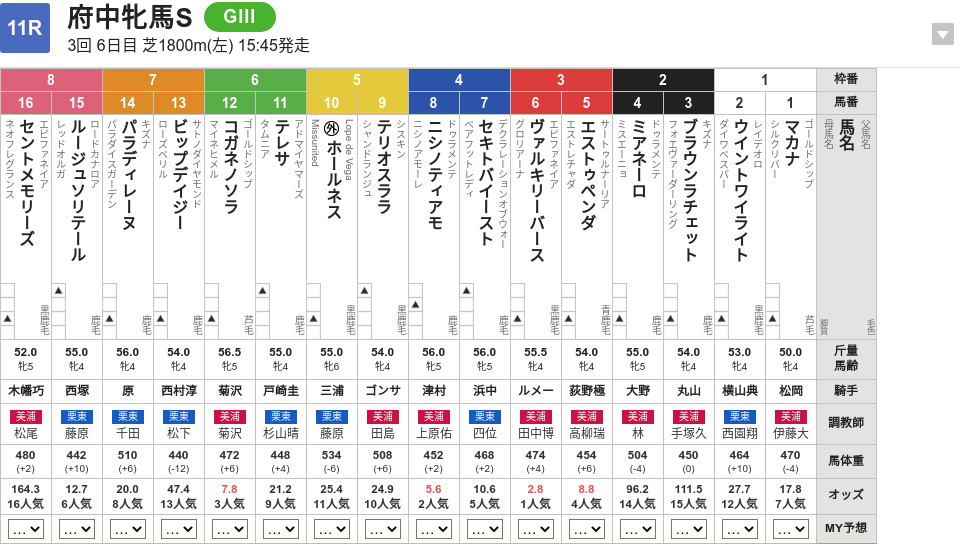

### 【しらさぎステークス 2026/06/21(日) 】

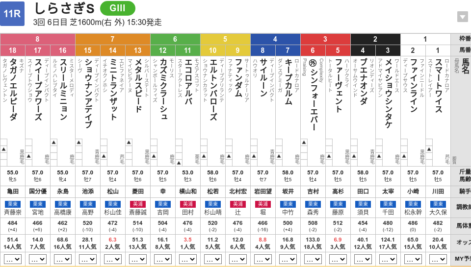

## 4. 単勝予測結果

| 枠番 | 馬番 | 人気 | オッズ | 馬名 | 騎手 | 調教師 | 予測タイム(sec) | 1_順位 | 1-3着内確率(%) | 2_順位 | ﾀﾞｰｸﾎｰｽ確率(%) | 3_順位 |
| --- | --- | --- | --- | --- | --- | --- | --- | --- | --- | --- | --- | --- |
| 1 | 1 | 7 | 17.5 | マカナ | 松岡正海 | 伊藤大士 | 116.4 | 14.0 | 10.9 | 9 | 0.8 | 14 |
| 1 | 2 | 12 | 27.1 | ウイントワイライト | 横山典弘 | 西園翔太 | 108.4 | 6.0 | 10.0 | 10 | 41.6 | 3 |
| 2 | 3 | 15 | 107.9 | ブラウンラチェット | 丸山元気 | 手塚貴久 | 104.7 | 1.5 | 15.0 | 6 | 52.7 | 1 |
| 2 | 4 | 14 | 94.1 | ミアネーロ | 大野拓弥 | 林徹 | 116.2 | 13.0 | 3.4 | 16 | 14.3 | 8 |
| 3 | 5 | 4 | 8.9 | エストゥペンダ | 荻野極 | 高柳瑞樹 | 108.4 | 7.0 | 27.1 | 2 | 1.2 | 11 |
| 3 | 6 | 1 | 2.9 | ヴァルキリーバース | Ｃ．ルメール | 田中博康 | 104.7 | 1.5 | 15.9 | 4 | 0.5 | 15 |
| 4 | 7 | 5 | 10.6 | セキトバイースト | 浜中俊 | 四位洋文 | 117.1 | 15.0 | 9.2 | 11 | 1.0 | 13 |
| 4 | 8 | 2 | 5.6 | ニシノティアモ | 津村明秀 | 上原佑紀 | 110.8 | 11.0 | 29.2 | 1 | 0.5 | 16 |
| 5 | 9 | 11 | 25.5 | テリオスララ | Ｆ．ゴンサルベス | 田島俊明 | 108.4 | 8.0 | 7.5 | 13 | 32.8 | 6 |
| 5 | 10 | 10 | 24.9 | ホールネス | 三浦皇成 | 藤原英昭 | 110.0 | 10.0 | 7.4 | 14 | 37.0 | 5 |

[output cut: 6 more lines]

### 【しらさぎステークス(GⅢ) 2026/06/21(日)】

| 枠番 | 馬番 | 人気 | オッズ | 馬名 | 騎手 | 調教師 | 予測タイム(sec) | 1_順位 | 1-3着内確率(%) | 2_順位 | ﾀﾞｰｸﾎｰｽ確率(%) | 3_順位 |
| --- | --- | --- | --- | --- | --- | --- | --- | --- | --- | --- | --- | --- |
| 1 | 1 | 10 | 19.7 | スマートワイス | 川田将雅 | 大久保龍志 | 92.2 | 7 | 9.5 | 12 | 27.3 | 6 |
| 1 | 2 | 15 | 58.7 | ファインライン | 小崎綾也 | 松永幹夫 | 99.6 | 13 | 2.3 | 18 | 12.0 | 9 |
| 2 | 3 | 17 | 116.2 | メイショウシンタケ | 太宰啓介 | 千田輝彦 | 99.2 | 12 | 2.8 | 16 | 13.9 | 8 |
| 2 | 4 | 12 | 37.2 | ブエナオンダ | 田口貫太 | 須貝尚介 | 97.3 | 11 | 5.8 | 14 | 36.6 | 4 |
| 3 | 5 | 2 | 6.9 | ファーヴェント | 高杉吏麒 | 藤原英昭 | 90.7 | 2 | 28.4 | 1 | 1.0 | 15 |
| 3 | 6 | 18 | 122.6 | シンフォーエバー | 吉村誠之助 | 森秀行 | 91.3 | 3 | 10.4 | 11 | 44.5 | 1 |
| 4 | 7 | 9 | 17.2 | キープカルム | 坂井瑠星 | 中竹和也 | 93.6 | 8 | 17.4 | 5 | 1.5 | 10 |
| 4 | 8 | 4 | 8.6 | サイルーン | 岩田望来 | 堀宣行 | 99.7 | 14 | 12.7 | 6 | 0.8 | 17 |
| 5 | 9 | 6 | 11.7 | ファンダム | 北村宏司 | 辻哲英 | 91.9 | 6 | 22.1 | 3 | 1.3 | 11 |
| 5 | 10 | 5 | 10.8 | エルトンバローズ | 松若風馬 | 杉山晴紀 | 99.8 | 15 | 12.0 | 7 | 0.8 | 16 |

[output cut: 8 more lines]

## 5. 人気と着順の乖離率推移

### 【府中牝馬ステークス_1992y_2019y】

[interactive chart not shown]

### 【府中牝馬ステークス_1992y_2019y】

| No | 開催年 | 不整合率(%) | 頭数 | 人気別着順(1-3位) | 人気別着順(全体) |
| --- | --- | --- | --- | --- | --- |
| 28 | 2019 | 56.2 | 15頭 | 4-9-2 | 4\|9\|2\|7\|3\|5\|12\|13\|10\|6\|15\|8\|11\|14\|1 |
| 27 | 2018 | 20.8 | 11頭 | 1-2-7 | 1\|2\|7\|4\|6\|8\|9\|10\|5\|3\|11 |
| 26 | 2017 | 19.5 | 14頭 | 5-1-2 | 5\|1\|2\|3\|7\|9\|13\|8\|12\|4\|10\|6\|14\|11 |
| 25 | 2016 | 47.3 | 13頭 | 3-2-1 | 3\|2\|1\|7\|5\|6\|8\|12\|11\|4\|13\|9\|10 |
| 24 | 2015 | 43.3 | 17頭 | 11-1-5 | 11\|1\|5\|17\|15\|14\|4\|7\|3\|12\|16\|6\|9\|8\|2\|10\|13 |
| 23 | 2014 | 22.8 | 13頭 | 4-1-2 | 4\|1\|2\|3\|7\|6\|9\|5\|10\|13\|11\|8\|12 |
| 22 | 2013 | 50.3 | 13頭 | 4-5-7 | 4\|5\|7\|2\|10\|6\|8\|1\|3\|11\|12\|13\|9 |
| 21 | 2012 | 41.3 | 17頭 | 10-5-1 | 10\|5\|1\|9\|3\|8\|4\|6\|14\|7\|2\|11\|12\|16\|15\|17\|13 |
| 20 | 2011 | 72.3 | 16頭 | 5-4-3 | 5\|4\|3\|11\|7\|8\|14\|2\|6\|13\|9\|12\|10\|1\|16\|15 |
| 19 | 2010 | 50.0 | 17頭 | 4-14-2 | 4\|14\|2\|8\|13\|3\|7\|9\|1\|5\|10\|12\|15\|11\|17\|6\|16 |

[output cut: 18 more lines]

## 6. 1-3番人気馬の着順分類予測

### 【府中牝馬ステークス】

| 分類 | 凡例 | 発生確率(%) | 当該レース | 当該レースランク | 直近1年間 |
| --- | --- | --- | --- | --- | --- |
| 1: 1番人気のみ (1_pop1) | 1 \| * \| * | 17.9 | 1.02 | 1.35 | 0.00 |
| 4: 1,2番人気のみ (4_pop12) | 1 \| 2 \| * | 17.1 | 0.83 | 0.85 | 0.00 |
| 8: 1,2,3番人気すべて着外 (8_darkhorse) | * \| * \| * | 13.4 | 2.27 | 2.00 | 0.00 |
| 5: 1,3番人気のみ (5_pop13) | 1 \| 3 \| * | 13.3 | 0.90 | 0.00 | 0.00 |
| 2: 2番人気のみ (2_pop2) | 2 \| * \| * | 12.0 | 0.45 | 0.26 | 0.12 |
| 3: 3番人気のみ (3_pop3) | 3 \| * \| * | 9.9 | 1.13 | 1.48 | 0.00 |
| 6: 2,3番人気のみ (6_pop23) | 2 \| 3 \| * | 8.7 | 0.00 | 0.00 | 0.00 |
| 7: 1,2,3番人気すべて着内 (7_pop123) | 1 \| 2 \| 3 | 7.6 | 1.29 | 1.13 | 0.00 |

## 7. 3連複予測結果

| 分類 | 馬番 | 枠番 | 人気 | 平均予測タイム(sec) | 1-3着内確率(%) | ﾀﾞｰｸﾎｰｽ確率(%) | 馬名 | 騎手 | 調教師 |
| --- | --- | --- | --- | --- | --- | --- | --- | --- | --- |
| 2: 2番人気のみ (2_pop2) | 8-5-15 | 4-3-8 | 2-4-6 | 109.17 | 1.70 | 0.00 | ニシノティアモ \| エストゥペンダ \| ルージュソリテール | 津村明秀 \| 荻野極 \| 西塚洸二 | 上原佑紀 \| 高柳瑞樹 \| 藤原英昭 |
| 4: 1,2番人気のみ (4_pop12) | 6-8-5 | 3-4-3 | 1-2-4 | 107.97 | 1.25 | 0.00 | ヴァルキリーバース \| ニシノティアモ \| エストゥペンダ | Ｃ．ルメール \| 津村明秀 \| 荻野極 | 田中博康 \| 上原佑紀 \| 高柳瑞樹 |
| 2: 2番人気のみ (2_pop2) | 8-5-14 | 4-3-7 | 2-4-8 | 109.17 | 1.21 | 0.00 | ニシノティアモ \| エストゥペンダ \| パラディレーヌ | 津村明秀 \| 荻野極 \| 原優介 | 上原佑紀 \| 高柳瑞樹 \| 千田輝彦 |
| 2: 2番人気のみ (2_pop2) | 8-5-3 | 4-3-2 | 2-4-15 | 107.97 | 1.19 | 0.00 | ニシノティアモ \| エストゥペンダ \| ブラウンラチェット | 津村明秀 \| 荻野極 \| 丸山元気 | 上原佑紀 \| 高柳瑞樹 \| 手塚貴久 |
| 2: 2番人気のみ (2_pop2) | 8-5-11 | 4-3-6 | 2-4-9 | 109.17 | 1.15 | 0.00 | ニシノティアモ \| エストゥペンダ \| テレサ | 津村明秀 \| 荻野極 \| 戸崎圭太 | 上原佑紀 \| 高柳瑞樹 \| 杉山晴紀 |
| 4: 1,2番人気のみ (4_pop12) | 6-8-15 | 3-4-8 | 1-2-6 | 107.93 | 0.99 | 0.00 | ヴァルキリーバース \| ニシノティアモ \| ルージュソリテール | Ｃ．ルメール \| 津村明秀 \| 西塚洸二 | 田中博康 \| 上原佑紀 \| 藤原英昭 |
| 2: 2番人気のみ (2_pop2) | 8-15-14 | 4-8-7 | 2-6-8 | 109.13 | 0.96 | 0.00 | ニシノティアモ \| ルージュソリテール \| パラディレーヌ | 津村明秀 \| 西塚洸二 \| 原優介 | 上原佑紀 \| 藤原英昭 \| 千田輝彦 |
| 2: 2番人気のみ (2_pop2) | 8-15-3 | 4-8-2 | 2-6-15 | 107.93 | 0.94 | 0.00 | ニシノティアモ \| ルージュソリテール \| ブラウンラチェット | 津村明秀 \| 西塚洸二 \| 丸山元気 | 上原佑紀 \| 藤原英昭 \| 手塚貴久 |
| 1: 1番人気のみ (1_pop1) | 6-5-15 | 3-3-8 | 1-4-6 | 107.13 | 0.92 | 0.00 | ヴァルキリーバース \| エストゥペンダ \| ルージュソリテール | Ｃ．ルメール \| 荻野極 \| 西塚洸二 | 田中博康 \| 高柳瑞樹 \| 藤原英昭 |
| 2: 2番人気のみ (2_pop2) | 8-15-11 | 4-8-6 | 2-6-9 | 109.13 | 0.91 | 0.00 | ニシノティアモ \| ルージュソリテール \| テレサ | 津村明秀 \| 西塚洸二 \| 戸崎圭太 | 上原佑紀 \| 藤原英昭 \| 杉山晴紀 |

[output cut: 550 more lines]

### 【しらさぎステークス(GⅢ) 2026/06/21(日)】

| 分類 | 馬番 | 枠番 | 人気 | 平均予測タイム(sec) | 1-3着内確率(%) | ﾀﾞｰｸﾎｰｽ確率(%) | 馬名 | 騎手 | 調教師 |
| --- | --- | --- | --- | --- | --- | --- | --- | --- | --- |
| 6: 2,3番人気のみ (6_pop23) | 5-14-9 | 3-7-5 | 2-3-6 | 91.50 | 1.72 | 0.00 | ファーヴェント \| ミニトランザット \| ファンダム | 高杉吏麒 \| 松山弘平 \| 北村宏司 | 藤原英昭 \| 杉山佳明 \| 辻哲英 |
| 7: 1,2,3番人気すべて着内 (7_pop123) | 11-5-14 | 6-3-7 | 1-2-3 | 90.97 | 1.43 | 0.00 | エコロアルバ \| ファーヴェント \| ミニトランザット | 横山和生 \| 高杉吏麒 \| 松山弘平 | 田村康仁 \| 藤原英昭 \| 杉山佳明 |
| 6: 2,3番人気のみ (6_pop23) | 5-14-7 | 3-7-4 | 2-3-9 | 92.07 | 1.36 | 0.00 | ファーヴェント \| ミニトランザット \| キープカルム | 高杉吏麒 \| 松山弘平 \| 坂井瑠星 | 藤原英昭 \| 杉山佳明 \| 中竹和也 |
| 4: 1,2番人気のみ (4_pop12) | 11-5-9 | 6-3-5 | 1-2-6 | 90.97 | 1.15 | 0.00 | エコロアルバ \| ファーヴェント \| ファンダム | 横山和生 \| 高杉吏麒 \| 北村宏司 | 田村康仁 \| 藤原英昭 \| 辻哲英 |
| 5: 1,3番人気のみ (5_pop13) | 11-14-9 | 6-7-5 | 1-3-6 | 91.37 | 1.11 | 0.00 | エコロアルバ \| ミニトランザット \| ファンダム | 横山和生 \| 松山弘平 \| 北村宏司 | 田村康仁 \| 杉山佳明 \| 辻哲英 |
| 2: 2番人気のみ (2_pop2) | 5-9-7 | 3-5-4 | 2-6-9 | 92.07 | 1.09 | 0.00 | ファーヴェント \| ファンダム \| キープカルム | 高杉吏麒 \| 北村宏司 \| 坂井瑠星 | 藤原英昭 \| 辻哲英 \| 中竹和也 |
| 3: 3番人気のみ (3_pop3) | 14-9-7 | 7-5-4 | 3-6-9 | 92.47 | 1.06 | 0.00 | ミニトランザット \| ファンダム \| キープカルム | 松山弘平 \| 北村宏司 \| 坂井瑠星 | 杉山佳明 \| 辻哲英 \| 中竹和也 |
| 6: 2,3番人気のみ (6_pop23) | 5-14-8 | 3-7-4 | 2-3-4 | 94.10 | 0.98 | 0.00 | ファーヴェント \| ミニトランザット \| サイルーン | 高杉吏麒 \| 松山弘平 \| 岩田望来 | 藤原英昭 \| 杉山佳明 \| 堀宣行 |
| 6: 2,3番人気のみ (6_pop23) | 5-14-10 | 3-7-5 | 2-3-5 | 94.13 | 0.93 | 0.00 | ファーヴェント \| ミニトランザット \| エルトンバローズ | 高杉吏麒 \| 松山弘平 \| 松若風馬 | 藤原英昭 \| 杉山佳明 \| 杉山晴紀 |
| 6: 2,3番人気のみ (6_pop23) | 5-14-18 | 3-7-8 | 2-3-14 | 92.20 | 0.91 | 0.00 | ファーヴェント \| ミニトランザット \| タガノエルピーダ | 高杉吏麒 \| 松山弘平 \| 亀田温心 | 藤原英昭 \| 杉山佳明 \| 斉藤崇史 |

[output cut: 806 more lines]

## 8. 直近の全レース情報

[output not shown]

[output cut: 8 more lines]